# Outlier and Venn Diagram Results from Pinus contorta at different cutoffs for TASSEL

Katie Lotterhos

May 26, 2015

Data used here is stored on hulk at /data/seqcap/pine/bwa_pseudo/round2_bams/var_out_GATK3_allhet_pine688_ALL.summary.ALL.annots.sorted.GOOD.window_RESULTS. It was transferred to my laptop to make the markdown files

### The SNP dataset

Here are the column names in the SNP dataset: (the ones named after the environments contain Bayes Factors. “rho” represents Spearman’s rho, which indicates the correlation between the reference SNP frequency and the environment.)

```r
#filename <- "var_out_GATK3_allhet_pine688_ALL.summary.ALL.annots.sorted.GOOD.window.3xbf.log10"
filename <- "../pine_data/var_out_GATK3_allhet_pine688_ALL.summary.ALL.annots.sorted.GOOD.window_RESULTS.log10bf"
#filename <- "../pine_data/bayenv.lfmmbeagle.res"
### read in file with log-BF
  if(!("f2" %in% ls())){
    f2 <- read.table(filename, header=TRUE, comment.char="&")
  }
  names(f2)
```

```
##   [1] "gcontig"
##   [2] "gcontig__gcontig_pos"
##   [3] "pos_gcontig"
##   [4] "X_annotation"
##   [5] "paralogy_rank"
##   [6] "tcontig"
##   [7] "pos_tcontig"
##   [8] "gmap_percentID"
##   [9] "offtarget_dist"
##  [10] "num_alleles"
##  [11] "num_ind"
##  [12] "num_comm_gtype"
##  [13] "major_allele"
##  [14] "major_num"
##  [15] "major_freq"
```

[output cut: 268 more lines]

```r
## PHENOTYPES, but notation "envi" kept for coding
phen <- c("Budset", "Budbreak", "Height_season_1", "Height_season_2", "Diameter",
          "Shoot_weight", "Root_weight", "Max_growth_rate", "Linear_growth_days",
          "X5_growth_complete_days", "X95_growth_complete_days",
          "X5_95_growth_days", "Fall_cold_injury", "Winter_cold_injury",
          "Spring_cold_injury", "root_wt__shoot_wt")

phen_names <- c(phen, "root_wt__shoot_wt_1")
phen_p <- c(paste(phen, "_p", sep=""), "root_wt__shoot_wt_p_1")
phen_slope <- c(paste(phen, "_snp_effect", sep=""), "root_wt__shoot_wt_snp_effect_1")

### Code for calculating the cutoffs
#phencols <- which(names(f2) %in% phen_p)
#allp <- unlist(f2[,phencols])
#source("get.cutoffs.R")
#a<- get.cutoffs.p(allp)
#a
#write.table(a, "../pine_data/phenotype_p.cutoffs", row.names=FALSE)
```

## TO DO

calculate p-value cutoffs for the phenotypes and write to file

The total number of SNPs used for analysis:

```r
nrow(f2)
```

```
## [1] 1251074
```

```r
### read in file with cutoffs
  cos <- read.table("../pine_data/phenotype_p.cutoffs", header=TRUE)
  cos <- rev(cos)
  cos[1] <- 1
  names(cos)[1] <- "All"
  cos
```

```
##   All     V.90      V.95      V.99      V.999      V.9995     V.9999
## 1   1 0.111923 0.0581275 0.0124671 0.00129244 0.000631268 0.00010214
##       V.99999
## 1 2.81024e-06
```

#### Now loop through some these cutoffs and summarize the results for environment enrichment:

### Results for V.99 percentile, which corresponds to a log10 p-value of 0.0124671 …

#### Total number of outliers (loci with p-value below threshold in any one phenotype): 128134

### Results for V.999 percentile, which corresponds to a log10 p-value of 0.00129244 …

#### Total number of outliers (loci with p-value below threshold in any one phenotype): 15160

### Results for V.9995 percentile, which corresponds to a log10 p-value of 0.000631268 …

#### Total number of outliers (loci with p-value below threshold in any one phenotype): 7847

### Results for V.9999 percentile, which corresponds to a log10 p-value of 0.00010214 …

#### Total number of outliers (loci with p-value below threshold in any one phenotype): 1679

### Results for V.99999 percentile, which corresponds to a log10 p-value of 2.81024e-06 …

#### Total number of outliers (loci with p-value below threshold in any one phenotype): 203

### Number of outliers based on different cutoffs

#### The number of outliers in each phenotype

|  | phen_names | numOutliers.All | numOutliers.V.99 | numOutliers.V.999 | numOutliers.V.9995 | numOutliers.V.9999 | numOutliers.V.99999 |
| --- | --- | --- | --- | --- | --- | --- | --- |
| 1 | Budset | 1250519.00 | 8505.00 | 631.00 | 258.00 | 35.00 | 1.00 |
| 2 | Budbreak | 1250573.00 | 8808.00 | 713.00 | 312.00 | 31.00 | 1.00 |
| 3 | Height_season_1 | 1250631.00 | 8925.00 | 590.00 | 242.00 | 26.00 | 0.00 |
| 4 | Height_season_2 | 1250629.00 | 9870.00 | 731.00 | 320.00 | 34.00 | 1.00 |
| 5 | Diameter | 1250631.00 | 12958.00 | 1162.00 | 551.00 | 63.00 | 0.00 |
| 6 | Shoot_weight | 1250615.00 | 10918.00 | 873.00 | 405.00 | 54.00 | 0.00 |
| 7 | Root_weight | 1250614.00 | 11626.00 | 966.00 | 424.00 | 49.00 | 0.00 |
| 8 | Max_growth_rate | 1250628.00 | 15321.00 | 1667.00 | 825.00 | 145.00 | 6.00 |
| 9 | Linear_growth_days | 1250627.00 | 20203.00 | 2408.00 | 1241.00 | 246.00 | 18.00 |
| 10 | X5_growth_complete_days | 1250629.00 | 16056.00 | 3319.00 | 2155.00 | 846.00 | 173.00 |
| 11 | X95_growth_complete_days | 1250627.00 | 13882.00 | 1306.00 | 622.00 | 104.00 | 2.00 |
| 12 | X5_95_growth_days | 1250629.00 | 16996.00 | 1706.00 | 825.00 | 143.00 | 2.00 |
| 13 | Fall_cold_injury | 1248034.00 | 12313.00 | 1232.00 | 623.00 | 117.00 | 7.00 |
| 14 | Winter_cold_injury | 1250628.00 | 9877.00 | 745.00 | 316.00 | 26.00 | 0.00 |
| 15 | Spring_cold_injury | 1250615.00 | 12132.00 | 1219.00 | 592.00 | 83.00 | 1.00 |
| 16 | root_wt_*shoot*wt | 1250613.00 | 12639.00 | 1046.00 | 480.00 | 66.00 | 0.00 |
| 17 | root_wt_*shoot*wt_1 | 1250616.00 | 11548.00 | 943.00 | 437.00 | 57.00 | 0.00 |

### Proportion of outliers based on different cutoffs

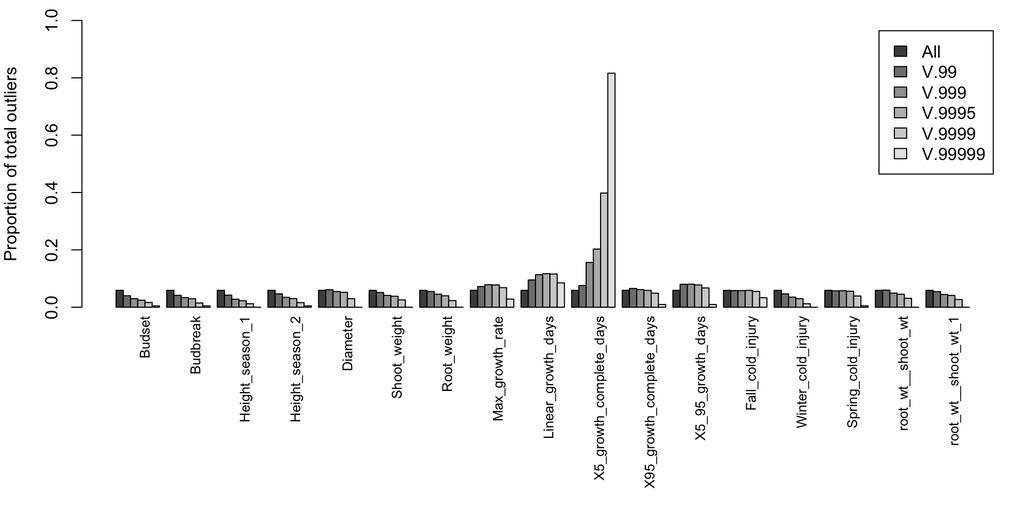

Looks like 5 complete days of growth has a lot of SNPs with very significant associations! Other growth variables are also enriched. I’m not sure what this means? SNPs have stronger associations with growth than with other traits?

#### Now loop through some these cutoffs and summarize the results for enrichment of different genomic categories:

There are two approaches toward looking at enrichment: based on annotation category, or based on the set of non-coding SNPs used in the covariance matrix.

##### Results based on annotation category

Here, for each locus I used the minimum p-value observed in any one environment. Then, I made a new annotation category that lumped together all non-synomymous SNPs. Next, I compared the proportion of SNPs in each annotation category for progressively more stringent cutoffs:

```r
  levels(f2$X_annotation)
```

```
##   [1] "3primeFLANK"     "3primeUTR"       "5primeFLANK"
##   [4] "5primeUTR"       "HAS_INDEL"       "intron"
##   [7] "mismatch_altref" "multi-allelic"   "non_tcontig"
##  [10] "nonsyn___to_C"   "nonsyn___to_E"   "nonsyn___to_G"
##  [13] "nonsyn___to_K"   "nonsyn___to_L"   "nonsyn___to_Q"
##  [16] "nonsyn___to_R"   "nonsyn___to_S"   "nonsyn___to_W"
##  [19] "nonsyn___to_Y"   "nonsyn_A_to_D"   "nonsyn_A_to_E"
##  [22] "nonsyn_A_to_G"   "nonsyn_A_to_P"   "nonsyn_A_to_S"
##  [25] "nonsyn_A_to_T"   "nonsyn_A_to_V"   "nonsyn_C_to__"
##  [28] "nonsyn_C_to_F"   "nonsyn_C_to_G"   "nonsyn_C_to_R"
##  [31] "nonsyn_C_to_S"   "nonsyn_C_to_W"   "nonsyn_C_to_Y"
##  [34] "nonsyn_D_to_A"   "nonsyn_D_to_E"   "nonsyn_D_to_G"
##  [37] "nonsyn_D_to_H"   "nonsyn_D_to_N"   "nonsyn_D_to_V"
##  [40] "nonsyn_D_to_Y"   "nonsyn_E_to__"   "nonsyn_E_to_A"
##  [43] "nonsyn_E_to_D"   "nonsyn_E_to_G"   "nonsyn_E_to_K"
```

[output cut: 46 more lines]

```r
### Make a new annotation category
    new.annot <- as.character(unlist(f2$X_annotation))
    new.annot[grep("nonsyn", f2$X_annotation)] <- "nonsyn"
    new.annot <- as.factor(new.annot)
    levels(new.annot)
```

```
##  [1] "3primeFLANK"     "3primeUTR"       "5primeFLANK"
##  [4] "5primeUTR"       "HAS_INDEL"       "intron"
##  [7] "mismatch_altref" "multi-allelic"   "non_tcontig"
## [10] "nonsyn"          "synonymous"      "unk_adj"
## [13] "unk_flank"       "UNKNOWN_ORF"
```

```
## [1] 15
## [1] 15
## [1] 15
## [1] 15
## [1] 15
```

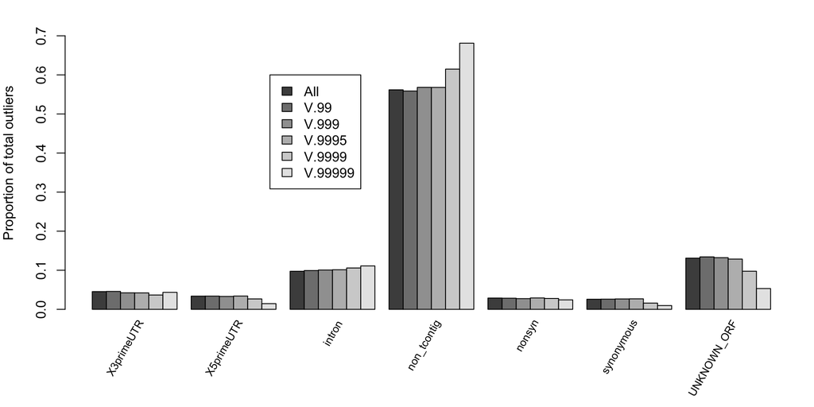

```r
### Calculate the max(BF) for a locus across all environments
  options(warn = -1)
  min.p <- apply(f2[,colBF], 1, min, na.rm=TRUE)
  min.p[is.infinite(min.p)]<-NA

### functions to get proportions
get.prop.newannot <- function(V, ind, rowname=NULL){
  a<- tapply(V[ind], new.annot[ind], length)
  a2<- data.frame(t(a/sum(a, na.rm=TRUE)))
  rownames(a2) <- rowname
  a2
  }

### For barplot, x-axis categories are in columns and colored bars are in rows
  enrich.new.annot <- data.frame(cutoff="All", get.prop.newannot(min.p, TRUE))

  cutoff2 <- as.numeric(cos[which.cutoffs[-1]])
  cutoff2names <- names(cos[which.cutoffs[-1]])
  for (i in 1:length(cutoff2)){
    n2 <- data.frame(cutoff=cutoff2names[i], get.prop.newannot(min.p, min.p<=cutoff2[i]) )
    print(length(n2))
    enrich.new.annot<- merge(enrich.new.annot, n2, all.x=TRUE, all.y=TRUE)
  }
```

The above results are SNP-based; they are probably driven by the significant outliers in the 5 growth days category.

#### Results based on proportion of noncoding SNPs used in covariance matrix

```r
levels(f2$noncode_in_covar)
```

```
## [1] "in_covar" "no"
```

```r
get.prop.noncod <- function(V, ind){
  a<- tapply(V[ind], f2$noncode_in_covar[ind], length)
  as.numeric((a/sum(a, na.rm=TRUE))[1])
  }

  enrich.noncod <- get.prop.noncod(min.p, TRUE)
  for (i in 1:length(cutoff2)){
    enrich.noncod <- c(enrich.noncod, get.prop.noncod(min.p, min.p<=cutoff2[i]) )
  }
  names(enrich.noncod) <- c("All", cutoff2names)
  enrich.noncod
```

```
##         All        V.99       V.999      V.9995      V.9999     V.99999
## 0.007995530 0.008364457 0.008736780 0.006591456 0.002955083          NA
```

#### Histogram of BF from noncoding SNPs used in covmat vs. other SNPs

```r
  log.min.p <- log10(min.p)
  low <- min(log.min.p, na.rm=TRUE)
 high <- max(log.min.p, na.rm=TRUE)
levels(f2$noncode_in_covar)
```

```
## [1] "in_covar" "no"
```

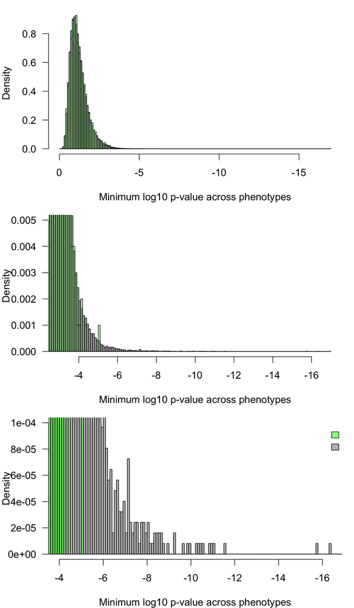

```r
#[1] "in_covar" "no"
  br <- seq(-17, 0, by=0.1)
  par(mfcol=c(3,1), mar=c(4,4,1,1), cex=1.2, las=1)

  hist(log.min.p[f2$noncode_in_covar=="no"], breaks=br, freq=FALSE, col="darkgrey", main="", xlab="Minimum log10 p-value across phenotypes", xlim=c(0,-17))
  hist(log.min.p[f2$noncode_in_covar=="in_covar"], breaks=br, freq=FALSE, add=TRUE, col=rgb(0,1,0,0.2))

  hist(log.min.p[f2$noncode_in_covar=="no"], breaks=br, xlim=c(-3, -17),
       freq=FALSE, ylim=c(0,0.005),
       main="", xlab="Minimum log10 p-value across phenotypes", col="darkgrey")
  hist(log.min.p[f2$noncode_in_covar=="in_covar"], breaks=br, freq=FALSE, add=TRUE, col=rgb(0,1,0,0.2))

  hist(log.min.p[f2$noncode_in_covar=="no"], breaks=br, xlim=c(-4, low), freq=FALSE, ylim=c(0,0.0001),  main="", xlab="Minimum log10 p-value across phenotypes", col="grey")
  hist(log.min.p[f2$noncode_in_covar=="in_covar"], breaks=br, freq=FALSE, add=TRUE, col=rgb(0,1,0,0.5))
  legend(-16,0.0001, c("Noncoding in covmat", "Not in covmat"), fill=c(rgb(0,1,0,0.5),"grey" ), bty="n")
```

The above three plots zoom in on the tail of the pvalue distribution. Note that the above plots are made with R’s *density()* on the y-axis, and this results in densities that are not to scale in the tail - I’ll work on that later. The above results are encouraging. The coding loci have smaller p-values than the noncoding loci that were used to create the covariance matrix. Note also that this argument is somewhat circular - maybe by using them to create the covariance matrix, we might over-correct for population structure and so they tend to have low associations.

### Enrichment analysis based on Sam’s “super-outlier-contig” status.